# 成為資料分析師 | Python 與資料科學應用

> Matplotlib 101：探索性分析與資料視覺化的 Python 套件

## 郭耀仁

## 大綱

- Matplotlib 解決了什麼問題
- 認識範例資料集：gapminder
- Matplotlib 基礎
- Matplotlib 技巧
- 延伸閱讀
- 作業

## Matplotlib 解決了什麼問題

## Matplotlib，或者更廣泛地說資料視覺化能夠將抽象資料轉換為具體的輸出

```python
import numpy as np
from numpy import pi

x = np.linspace(0, 4*pi)
f = np.sin(x)
print(x)
print(f)
```

```
[ 0.          0.25645654  0.51291309  0.76936963  1.02582617  1.28228272
  1.53873926  1.7951958   2.05165235  2.30810889  2.56456543  2.82102197
  3.07747852  3.33393506  3.5903916   3.84684815  4.10330469  4.35976123
  4.61621778  4.87267432  5.12913086  5.38558741  5.64204395  5.89850049
  6.15495704  6.41141358  6.66787012  6.92432667  7.18078321  7.43723975
  7.69369629  7.95015284  8.20660938  8.46306592  8.71952247  8.97597901
  9.23243555  9.4888921   9.74534864 10.00180518 10.25826173 10.51471827
 10.77117481 11.02763136 11.2840879  11.54054444 11.79700098 12.05345753
 12.30991407 12.56637061]
[ 0.00000000e+00  2.53654584e-01  4.90717552e-01  6.95682551e-01
  8.55142763e-01  9.58667853e-01  9.99486216e-01  9.74927912e-01
  8.86599306e-01  7.40277997e-01  5.45534901e-01  3.15108218e-01
  6.40702200e-02 -1.91158629e-01 -4.33883739e-01 -6.48228395e-01
 -8.20172255e-01 -9.38468422e-01 -9.95379113e-01 -9.87181783e-01
 -9.14412623e-01 -7.81831482e-01 -5.98110530e-01 -3.75267005e-01
 -1.27877162e-01  1.27877162e-01  3.75267005e-01  5.98110530e-01
  7.81831482e-01  9.14412623e-01  9.87181783e-01  9.95379113e-01
  9.38468422e-01  8.20172255e-01  6.48228395e-01  4.33883739e-01
  1.91158629e-01 -6.40702200e-02 -3.15108218e-01 -5.45534901e-01
 -7.40277997e-01 -8.86599306e-01 -9.74927912e-01 -9.99486216e-01
 -9.58667853e-01 -8.55142763e-01 -6.95682551e-01 -4.90717552e-01
 -2.53654584e-01 -4.89858720e-16]
```

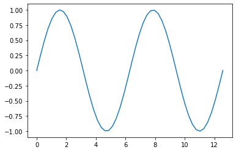

```python
%matplotlib inline
import matplotlib.pyplot as plt

fig = plt.figure()
ax = plt.axes()
ax.plot(x, f)
plt.show()
```

```python
def sigmoid(x):
    return 1 / (1 + np.exp(-x))

x = np.linspace(-10, 10)
f = sigmoid(x)
print(x)
print(f)
```

```
[-10.          -9.59183673  -9.18367347  -8.7755102   -8.36734694
  -7.95918367  -7.55102041  -7.14285714  -6.73469388  -6.32653061
  -5.91836735  -5.51020408  -5.10204082  -4.69387755  -4.28571429
  -3.87755102  -3.46938776  -3.06122449  -2.65306122  -2.24489796
  -1.83673469  -1.42857143  -1.02040816  -0.6122449   -0.20408163
   0.20408163   0.6122449    1.02040816   1.42857143   1.83673469
   2.24489796   2.65306122   3.06122449   3.46938776   3.87755102
   4.28571429   4.69387755   5.10204082   5.51020408   5.91836735
   6.32653061   6.73469388   7.14285714   7.55102041   7.95918367
   8.36734694   8.7755102    9.18367347   9.59183673  10.        ]
[4.53978687e-05 6.82792246e-05 1.02692018e-04 1.54446212e-04
 2.32277160e-04 3.49316192e-04 5.25297471e-04 7.89865942e-04
 1.18752721e-03 1.78503502e-03 2.68237328e-03 4.02898336e-03
 6.04752187e-03 9.06814944e-03 1.35769169e-02 2.02816018e-02
 3.01959054e-02 4.47353464e-02 6.58005831e-02 9.57904660e-02
 1.37437932e-01 1.93321370e-01 2.64947903e-01 3.51547277e-01
 4.49155938e-01 5.50844062e-01 6.48452723e-01 7.35052097e-01
 8.06678630e-01 8.62562068e-01 9.04209534e-01 9.34199417e-01
 9.55264654e-01 9.69804095e-01 9.79718398e-01 9.86423083e-01
 9.90931851e-01 9.93952478e-01 9.95971017e-01 9.97317627e-01
 9.98214965e-01 9.98812473e-01 9.99210134e-01 9.99474703e-01
 9.99650684e-01 9.99767723e-01 9.99845554e-01 9.99897308e-01
 9.99931721e-01 9.99954602e-01]
```

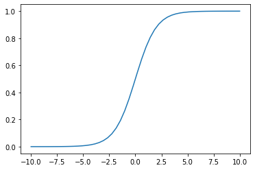

```python
fig = plt.figure()
ax = plt.axes()
ax.plot(x, f)
plt.show()
```

## 認識範例資料集：gapminder

## 視覺化的典範

- [Minard's map of Napoleon's disastrous Russian campaign of 1812](https://en.wikipedia.org/wiki/Flow_map#/media/File:Minard.png)
- [Hans Rosling's 200 Countries, 200 Years, 4 Minutes](https://youtu.be/jbkSRLYSojo)

## 關於 Gapminder, Hans Rosling 與 Factfulness

- [Gapminder](https://www.gapminder.org/)
- [Hans Rosling](https://en.wikipedia.org/wiki/Hans_Rosling)
- [Factfulness](https://www.youtube.com/watch?v=5uooRe07mYM)

## 獲得 gapminder 範例資料集

```python
import pandas as pd

csv_url = "https://storage.googleapis.com/learn_pd_like_tidyverse/gapminder.csv"
gapminder = pd.read_csv(csv_url)
```

## 檢視 gapminder 範例資料集

```python
print(gapminder.shape)
gapminder.head()
```

```
(1704, 6)
```

|  | country | continent | year | lifeExp | pop | gdpPercap |
| --- | --- | --- | --- | --- | --- | --- |
| 0 | Afghanistan | Asia | 1952 | 28.801 | 8425333 | 779.445314 |
| 1 | Afghanistan | Asia | 1957 | 30.332 | 9240934 | 820.853030 |
| 2 | Afghanistan | Asia | 1962 | 31.997 | 10267083 | 853.100710 |
| 3 | Afghanistan | Asia | 1967 | 34.020 | 11537966 | 836.197138 |
| 4 | Afghanistan | Asia | 1972 | 36.088 | 13079460 | 739.981106 |

## 檢視 gapminder 範例資料集的文字欄位

```python
print(gapminder["country"].value_counts())
print(gapminder["continent"].value_counts())
```

```
Colombia             12
Finland              12
Greece               12
Comoros              12
Turkey               12
                     ..
Portugal             12
Singapore            12
Afghanistan          12
Equatorial Guinea    12
Congo, Dem. Rep.     12
Name: country, Length: 142, dtype: int64
Africa      624
Asia        396
Europe      360
Americas    300
Oceania      24
Name: continent, dtype: int64
```

## 檢視 gapminder 範例資料集的 `year` 變數

```python
print(gapminder["year"].value_counts())
```

```
2007    142
2002    142
1997    142
1992    142
1987    142
1982    142
1977    142
1972    142
1967    142
1962    142
1957    142
1952    142
Name: year, dtype: int64
```

## 其他檢視 gapminder 範例資料集的方法：數值欄位的描述性統計

```python
gapminder.describe()
```

|  | year | lifeExp | pop | gdpPercap |
| --- | --- | --- | --- | --- |
| count | 1704.00000 | 1704.000000 | 1.704000e+03 | 1704.000000 |
| mean | 1979.50000 | 59.474439 | 2.960121e+07 | 7215.327081 |
| std | 17.26533 | 12.917107 | 1.061579e+08 | 9857.454543 |
| min | 1952.00000 | 23.599000 | 6.001100e+04 | 241.165877 |
| 25% | 1965.75000 | 48.198000 | 2.793664e+06 | 1202.060309 |
| 50% | 1979.50000 | 60.712500 | 7.023596e+06 | 3531.846989 |
| 75% | 1993.25000 | 70.845500 | 1.958522e+07 | 9325.462346 |
| max | 2007.00000 | 82.603000 | 1.318683e+09 | 113523.132900 |